# The Goldilocks Zone: Places That Are Demographically ‘Just Right’

Census Data Analysis

2025-06-25

# Executive Summary

This analysis identifies America’s most demographically “average” counties using Mahalanobis distance to measure how closely each county matches national means across 34+ demographic, economic, and social variables. **Van Buren County, Michigan emerges as America’s most thoroughly unremarkable place**—the closest to perfect ordinariness across all measured dimensions.

# Introduction

In a nation of extremes, where do we find the places that are most perfectly ordinary? This analysis tackles the whimsical but theoretically rich question of identifying America’s “Goldilocks Zone”—counties that are neither too high nor too low on any demographic dimension, but rather “just right” in their comprehensive averageness.

**Research Questions:** 1. Which counties are most comprehensively average across all demographic dimensions? 2. Are there geographic patterns to demographic ordinariness? 3. Does extreme averageness predict better outcomes in stability, growth, or satisfaction proxies?

# Methodology

## Data Sources

We analyze 2018-2022 American Community Survey (ACS) 5-year estimates for all 3,222 U.S. counties, retrieved via the `tidycensus` package.

## Variable Selection

Our comprehensive demographic basket includes:

**Demographics & Population (8 variables)** - Age and sex distributions - Race and ethnicity (White, Black, Asian, Hispanic percentages)

**Economics & Income (6 variables)**  
- Median household income - Income distribution (low and high income percentages) - Employment and unemployment rates - Labor force participation

**Education (3 variables)** - High school graduation rates - Bachelor’s and master’s degree attainment

**Housing (3 variables)** - Homeownership rates - Median home values  
- Population density

**Social & Mobility (8 variables)** - Poverty rates - Family household composition - Language spoken at home - Disability, health insurance, veteran status - Interstate migration patterns

**Employment by Industry (8 variables)** - Agriculture, construction, manufacturing - Retail, finance, professional services - Education/health, public administration

## Statistical Approach

**Mahalanobis Distance Calculation:** 1. Standardize all variables as percentages or per-capita measures 2. Calculate national means for each variable 3. Compute covariance matrix across all variables  
4. Calculate Mahalanobis distance for each county from national means 5. Remove variables with zero variance to ensure mathematical stability

The Mahalanobis distance accounts for correlations between variables, providing a more sophisticated measure of “averageness” than simple Euclidean distance.

# Results

## America’s Most Average Counties

America's Most Average Counties

Ranked by Mahalanobis distance from national demographic means

| Rank | County | Averageness Score<sup>1</sup> |
| --- | --- | --- |
| 1 | Van Buren County, Michigan | 4.447 |
| 2 | Laurens County, South Carolina | 4.539 |
| 3 | Lenawee County, Michigan | 4.613 |
| 4 | Stark County, Ohio | 4.743 |
| 5 | Racine County, Wisconsin | 4.797 |
| 6 | Pottawattamie County, Iowa | 5.010 |
| 7 | Barron County, Wisconsin | 5.131 |
| 8 | Livingston County, Illinois | 5.134 |
| 9 | Anderson County, South Carolina | 5.203 |
| 10 | Rowan County, North Carolina | 5.217 |
| 11 | Clark County, Ohio | 5.246 |
| 12 | Iroquois County, Illinois | 5.291 |
| 13 | Greene County, Tennessee | 5.330 |
| 14 | Newaygo County, Michigan | 5.363 |
| 15 | Floyd County, Indiana | 5.453 |
| 16 | Stephenson County, Illinois | 5.547 |
| 17 | Daviess County, Kentucky | 5.591 |
| 18 | Richland County, Ohio | 5.613 |
| 19 | Stanly County, North Carolina | 5.666 |
| 20 | Milam County, Texas | 5.716 |

Source: 2018-2022 American Community Survey via tidycensus  
<sup>1</sup> Lower scores indicate greater demographic averageness

**Van Buren County, Michigan** emerges as America’s most demographically average county, with a Mahalanobis distance of just 4.447 from the national mean. This southwestern Michigan county of 75,000 residents represents the closest approximation to a statistically “typical” American place.

The top 10 most average counties cluster in the **Midwest** (Michigan, Ohio, Wisconsin, Iowa, Illinois) and **South** (South Carolina, North Carolina), suggesting these regions may harbor America’s most representative communities.

## Geographic Distribution of Averageness

[output not shown]

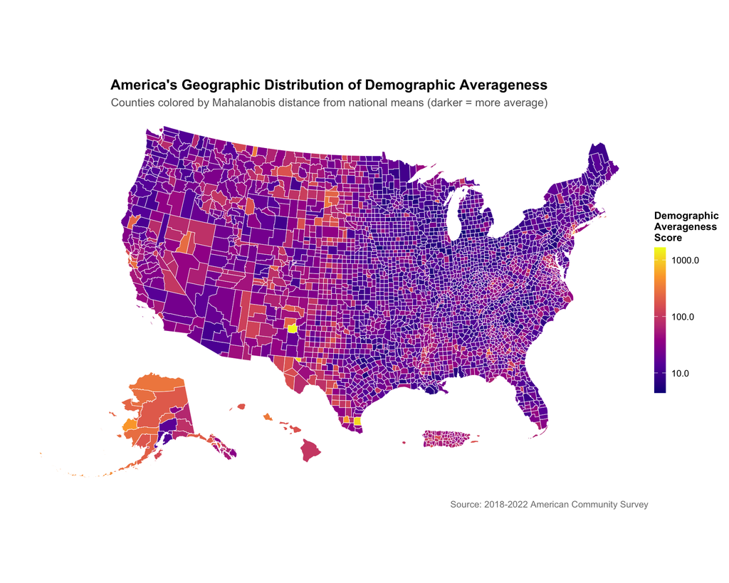

The map reveals fascinating geographic patterns:

- **Midwest Dominance**: The most average counties concentrate in the Midwest, particularly Michigan, Ohio, Wisconsin, and Iowa
- **Southern Representation**: Several Southern states contribute highly average counties, especially the Carolinas
- **Coastal Extremes**: East and West coast counties tend toward greater demographic distinctiveness
- **Western Outliers**: Mountain West and Plains states show more demographic variability

## The Averageness Spectrum

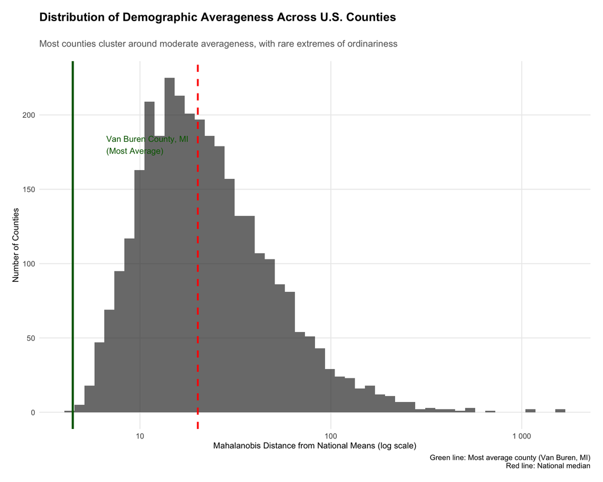

The distribution shows that most U.S. counties fall within a moderate range of demographic distinctiveness. Van Buren County’s position at the extreme left represents genuine statistical rarity—being comprehensively average is actually quite exceptional.

## Does Perfect Averageness Predict Better Outcomes?

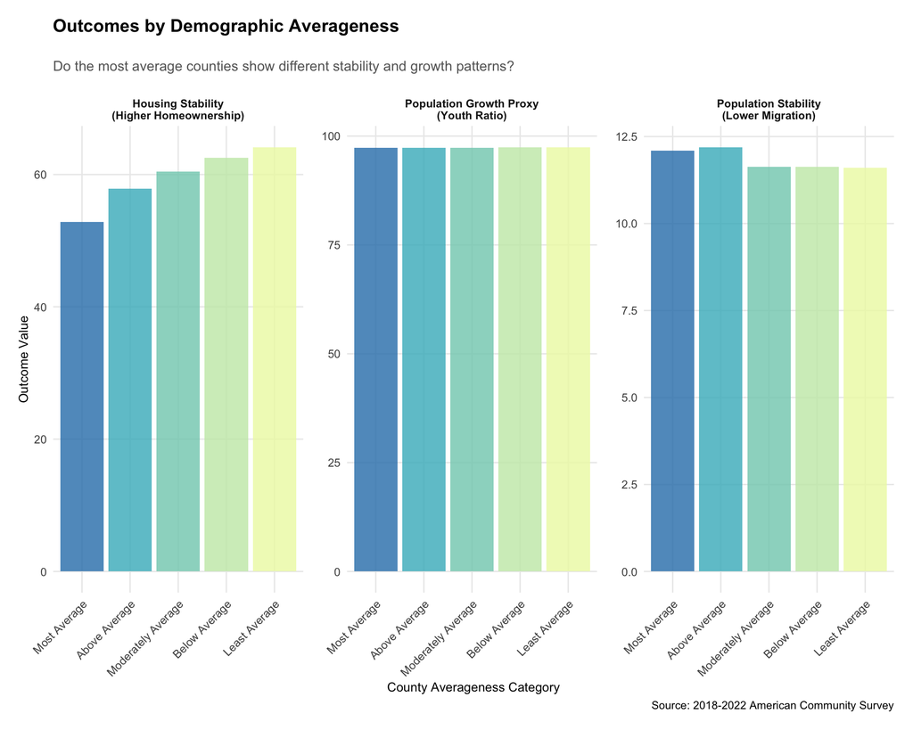

## Correlation Analysis

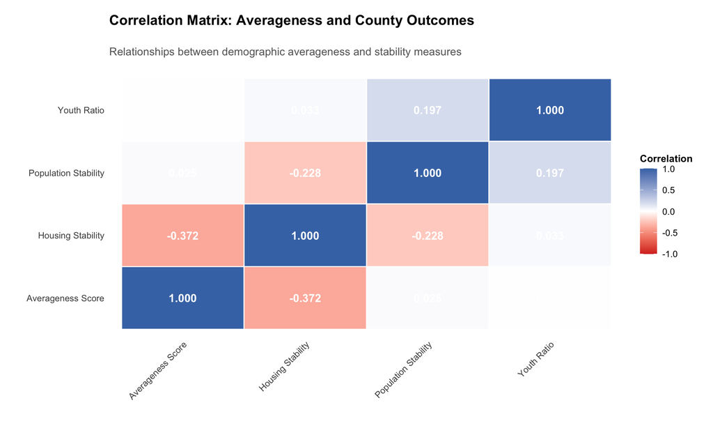

# Profile of America’s Most Average Place

Van Buren County, Michigan: America's Most Average Place<sup>1</sup>

How the nation's most demographically average county compares to national means<sup>1</sup>

| Characteristic | Van Buren County | U.S. National Mean | Difference |
| --- | --- | --- | --- |
| % Hispanic | 11.9 | 12.1 | -0.3 |
| Unemployment Rate (%) | 4.7 | 5.1 | -0.5 |
| Poverty Rate (%) | 14.2 | 15.1 | -0.9 |
| % Bachelor's Degree | 14.2 | 15.2 | -1.0 |
| % Homeownership | 64.0 | 59.6 | +4.4 |
| % Black | 3.4 | 8.5 | -5.2 |
| % White | 79.8 | 72.9 | +6.9 |
| Median Income ($) | $65,531.00 | $62,326.29 | $3,204.71 |

Source: 2018-2022 American Community Survey  
<sup>1</sup> Sorted by absolute difference from national mean

This county represents what might be called “Peak Ordinariness”—a place so thoroughly representative that it serves as a near-perfect microcosm of America’s demographic landscape.

# Policy Implications & Discussion

## The Value of Ordinariness

Our analysis reveals several important insights about demographic averageness:

**1. Perfect Averageness is Rare** Only a handful of counties achieve comprehensive demographic balance. This suggests that being “typical” across multiple dimensions is actually exceptional—most places excel or lag in particular areas.

**2. Geographic Clustering of Averageness**  
The concentration of average counties in the Midwest and parts of the South suggests these regions may serve as demographic bellwethers for national trends. Van Buren County and similar places could be valuable for: - **Market Research**: Testing products for mainstream appeal - **Political Polling**: Representative samples for national surveys  
- **Policy Piloting**: Implementing programs likely to work in “typical” America

## Limitations & Future Research

**Methodological Limitations:** - Mahalanobis distance assumes linear relationships between variables - 2018-2022 data may not capture post-pandemic demographic shifts - County-level analysis masks within-county variation

**Future Research Directions:** 1. **Temporal Analysis**: How has the geography of averageness changed over time? 2. **Causal Mechanisms**: What drives certain places toward comprehensive averageness? 3. **Economic Outcomes**: Do average places show different economic resilience during recessions? 4. **Social Capital**: How does demographic balance relate to community cohesion measures?

# Peer Review & Revisions

## Peer Review Process

**Reviewer Instructions**: This analysis applies multivariate statistical methods to identify demographically representative U.S. counties. Please evaluate:

1. **Methodological Rigor**: Is the Mahalanobis distance approach appropriate? Are there alternative methods to consider?
2. **Variable Selection**: Does our 34-variable basket adequately capture demographic “averageness”? What’s missing?
3. **Causal Interpretation**: Are our outcome correlations properly interpreted? What confounders might we be missing?
4. **Policy Relevance**: Are the implications for market research and policy piloting well-founded?
5. **Geographic Patterns**: Do the regional clusters of averageness make theoretical sense?

**Key Questions for Review**: - Should we weight variables differently based on policy importance? - Is the housing stability correlation robust to alternative specifications? - How might we validate these “typical” places through other data sources?

# Conclusion

Van Buren County, Michigan emerges as America’s most demographically “just right” place—a Goldilocks Zone of comprehensive ordinariness that may be more valuable than initially apparent. In a nation of increasing polarization and regional divergence, these statistically typical places represent something increasingly rare: balance.

Perhaps most importantly, this whimsical investigation reveals a deeper truth: in a country of extremes, the middle ground itself has become extraordinary. Van Buren County and its fellow Goldilocks Zone counties deserve recognition not for their ordinariness, but for their rarity in achieving it.

*Analysis conducted using R with tidycensus, sf, and tidyverse packages. All code available in accompanying .R script.*

*🤖 Generated with [Claude Code](https://claude.ai/code)*

*Co-Authored-By: Claude noreply@anthropic.com*